# Plots of Neuroblastoma Dataframe

Gepoliano Chaves

August 23rd, 2024

### References

The survival analysis reference used was writen by Zabor

- (Zabor 2023).

Transfer libraries

- (Jaeger 2015).

- (Kassambara 2017)

### Load libraries

```r
library(maditr)
```

# 1. Upload processed file (from R2 dataset)

Load the GSVA object back to the R environment. This object now contains all the metadata information.

```r
r2_gse62564_GSVA_Metadata <- readRDS( "../results/r2_gse62564_GSVA_Metadata.rds")
```

- In neuroblastoma, the main risk classification system classifies patients using features such as age, stage, histology and MYCN amplification status.
- Prognosis is the association between tumor features and patient survival.
- MYCN is a gene that encodes a transcription factor that is very important in tumor prognosis.
- Let’s take a look at the MYCN expression compared by the neuroblastoma risk group.
- First, let’s see which type of variable is the the MYCN status and the MYCN expression.

Check the class of the mycn_status variable:

```r
class(r2_gse62564_GSVA_Metadata$mycn_status)
```

```
## [1] "character"
```

Check the class of the MYCN variable

```r
class(r2_gse62564_GSVA_Metadata$MYCN)
```

```
## [1] "character"
```

They are both of type “character”. In order to plot, we have to make the MYCN expression to be of type numeric:

```r
r2_gse62564_GSVA_Metadata$MYCN <- as.numeric(r2_gse62564_GSVA_Metadata$MYCN)
```

Check again the class of the MYCN variable:

```r
class(r2_gse62564_GSVA_Metadata$MYCN)
```

```
## [1] "numeric"
```

### Check the age at diagnosis

Make age_at_diagnosis numeric to check age mean

```r
r2_gse62564_GSVA_Metadata$age_at_diagnosis <- as.numeric(r2_gse62564_GSVA_Metadata$age_at_diagnosis)
```

Check the mean age at diagnosis

```r
age_diagnosis_days_gse62564_498 <- mean(r2_gse62564_GSVA_Metadata$age_at_diagnosis)
age_diagnosis_days_gse62564_498
```

```
## [1] 758.5643
```

# 2. First Plots of the Neuroblastoma R2 Dataset

### MYCN Amplification status and MYCN expression

Let’s try and see the boxplot of the MYCN expression vs. MYCN amplification status.

Using the boxplot function that we tried before, we will have an error.

```r
boxplot(data=r2_gse62564_GSVA_Metadata, r2_gse62564_GSVA_Metadata$mycn_status, r2_gse62564_GSVA_Metadata$MYCN)
```

Maybe we could try the boxplot function making the mycn_status a numeric variable.

```r
boxplot(data=r2_gse62564_GSVA_Metadata, as.numeric(r2_gse62564_GSVA_Metadata$mycn_status), r2_gse62564_GSVA_Metadata$MYCN)
```

Let’s try and see if ggplot, which we have also used before, takes the mycn_status variable as categorical as it is right now.

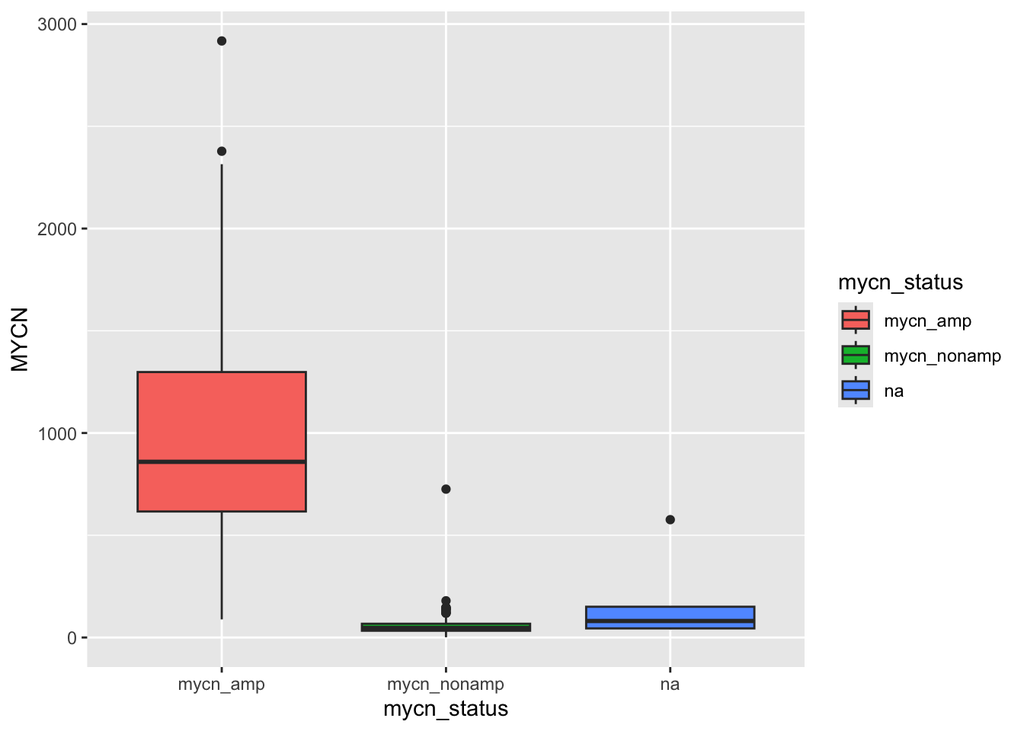

```r
library(ggplot2)
ggplot(r2_gse62564_GSVA_Metadata, aes(x=mycn_status, y=MYCN, fill=mycn_status)) +
    geom_boxplot()
```

In this figure, we see that group with clinical MYCN amplification, also shows high MYCN expression

What is the difference, in measurement, between MYCN amplification and MYCN expression?

How are the MYCN amplification and MYCN gene expression correlated?

For now, I am not bothering neither with formating of the X and Y labels nor with the N/A values of the MYCN amplification status.

### High Risk status and MYCN expression

We can plot the high risk status vs. MYCN amplification and leave the fill argument as mycn_status

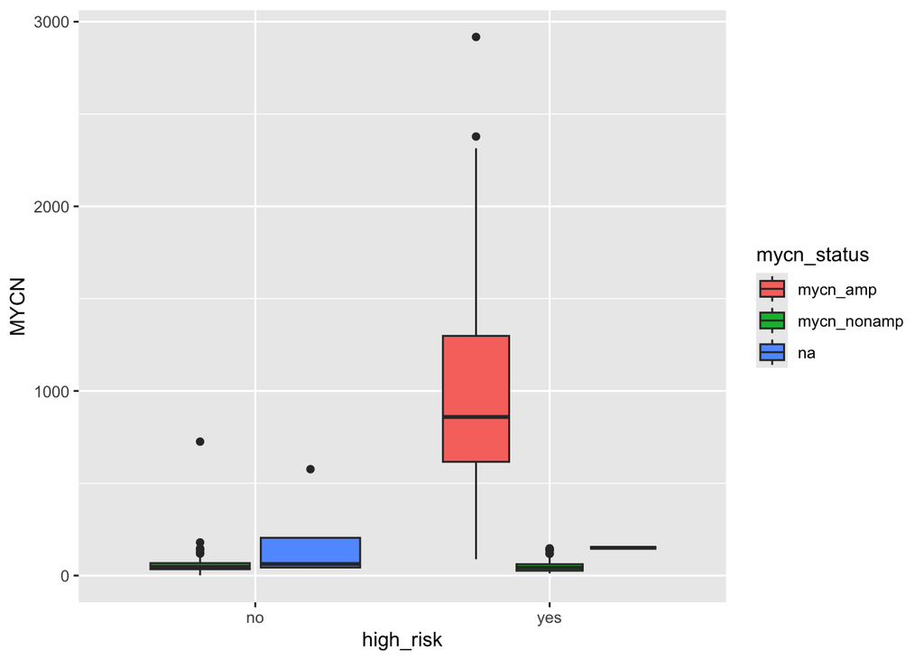

```r
library(ggplot2)
ggplot(r2_gse62564_GSVA_Metadata, aes(x=high_risk, y=MYCN, fill=mycn_status)) +
    geom_boxplot()
```

Or we can make it the high_risk status instead

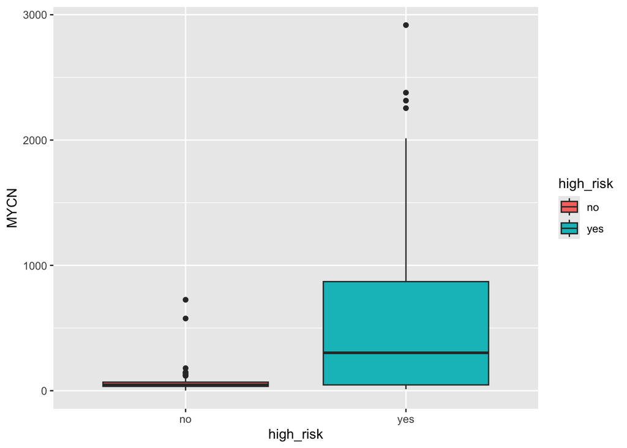

```r
library(ggplot2)
ggplot(r2_gse62564_GSVA_Metadata, aes(x=high_risk, y=MYCN, fill=high_risk)) +
    geom_boxplot()
```

Here we see that the high_risk status correlates positively with MYCN expression.

# 3. Survival Analysis

### Processing of variables to allow graph plotting

Make the OS (overall survival) status numeric, instead of character. Do the same for the EFS.

Construct os_bin_numeric from os_bin

```r
## OS
r2_gse62564_GSVA_Metadata <- r2_gse62564_GSVA_Metadata %>%
  dplyr::mutate(os_bin_numeric =
                  ifelse(r2_gse62564_GSVA_Metadata$os_bin == "event", "1", "0"))
```

Make os_bin_numeric as numeric

```r
r2_gse62564_GSVA_Metadata["os_bin_numeric"] <- as.numeric(r2_gse62564_GSVA_Metadata$os_bin_numeric)
```

```r
## EFS
r2_gse62564_GSVA_Metadata <- r2_gse62564_GSVA_Metadata %>%
  dplyr::mutate(efs_bin_numeric =
                  ifelse(r2_gse62564_GSVA_Metadata$efs_bin == "event", "1", "0"))
```

Make efs_bin_numeric as numeric

```r
r2_gse62564_GSVA_Metadata["efs_bin_numeric"] <- as.numeric(r2_gse62564_GSVA_Metadata$efs_bin_numeric)
```

### Survival Plots

Construct survival curve

```r
library(survival)
fit_os_high_risk <- survfit(Surv(as.numeric(os_day), os_bin_numeric) ~ r2_gse62564_GSVA_Metadata$high_risk,
                   data = r2_gse62564_GSVA_Metadata)
```

Plot survival curve w/o percents

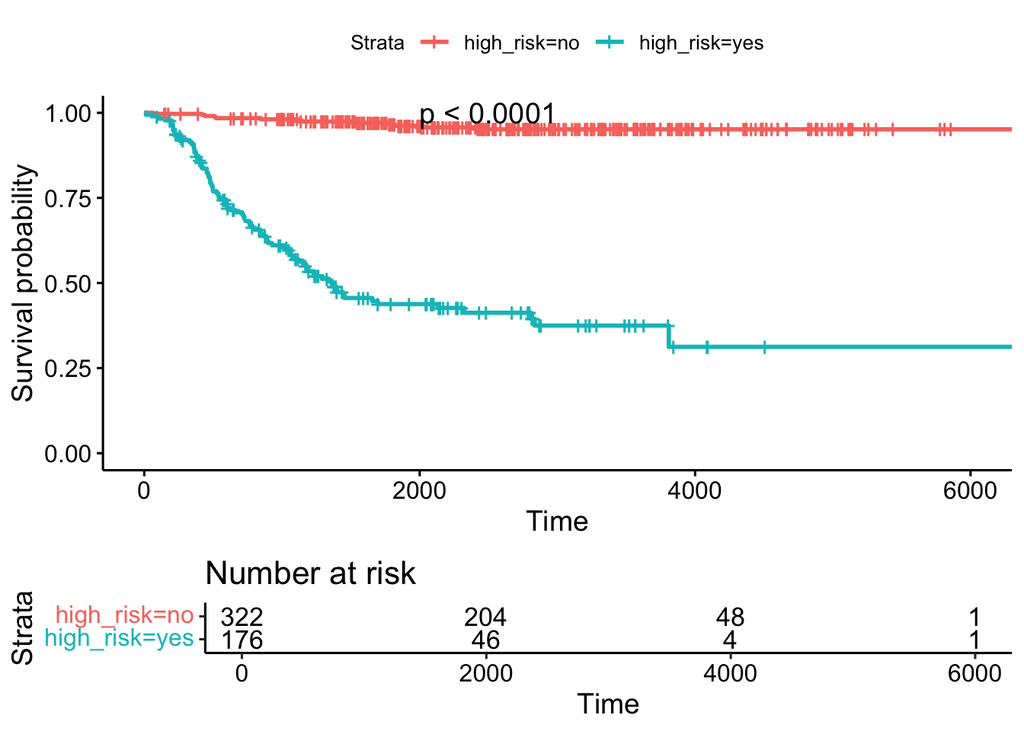

```r
library(survminer)
ggsurvplot(fit_os_high_risk,
           data = r2_gse62564_GSVA_Metadata,
           risk.table = TRUE,
           # risk.table = "abs_pct",
           pval = TRUE,
           pval.coord = c(2000, 1),
           )
```

Plot survival curve w/ percents

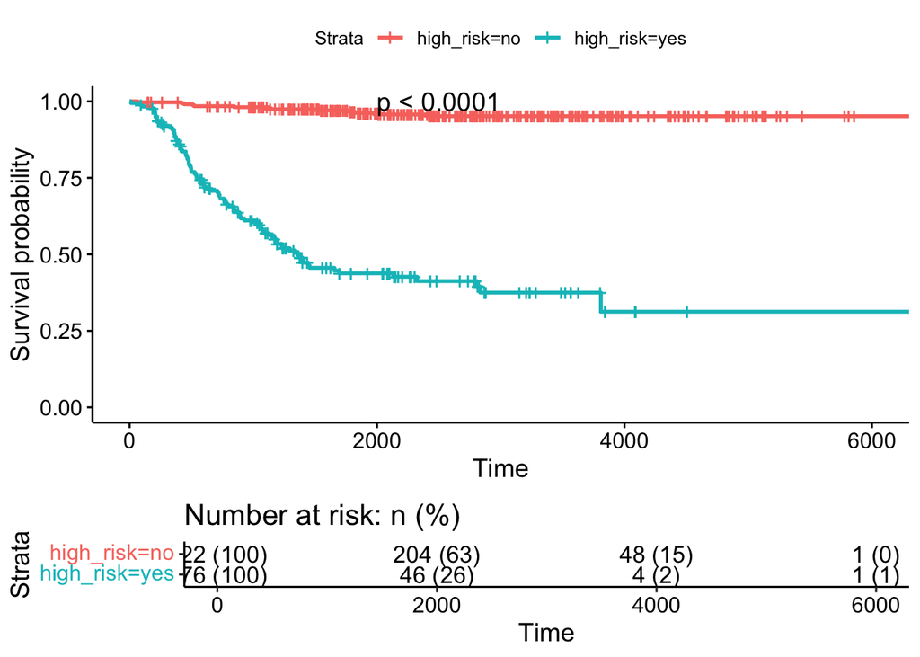

```r
ggsurvplot(fit_os_high_risk,
           data = r2_gse62564_GSVA_Metadata,
           # risk.table = TRUE,
           risk.table = "abs_pct",
           pval = TRUE,
           pval.coord = c(2000, 1),
           )
```

- Have students generate the EFS plot

# 4. Hypoxia in the Tumor Microenvironment

- Let’s now establish a relationship between neuroblastoma high risk status and hypoxia
- Hypoxia is the condition of low oxygen concentration that is established in the tumor microenvironment as cancer progresses.

### 4.1. HIF1A

- HIF1A is a transcription factor sensitive to oxygen levels;
- HIF1S is a single gene
- We need to make the HIF1A column (variable), numeric:

```r
r2_gse62564_GSVA_Metadata$HIF1A <- as.numeric(r2_gse62564_GSVA_Metadata$HIF1A)
```

Compare HIF1A means between the high risk groups using the compare_means() function

```r
compare_means(data = r2_gse62564_GSVA_Metadata, HIF1A ~ high_risk, method = "t.test")
```

| .y. | group1 | group2 | p | p.adj | p.format | p.signif | method |
| --- | --- | --- | --- | --- | --- | --- | --- |
| HIF1A | yes | no | 0.0003251992 | 0.00033 | 0.00033 | *** | T-test |

Plot high risk vs. HIF1A

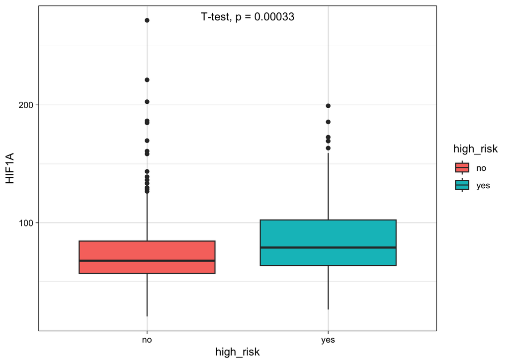

```r
ggplot(r2_gse62564_GSVA_Metadata, aes(x=high_risk, y=HIF1A, fill=high_risk)) +
    geom_boxplot()+
  stat_compare_means(method = "t.test", label.x = 1.4)+
  theme_linedraw()
```

### 4.2. HALLMARK_HYPOXIA

- This is one of the gene sets we talked about before;
- HALLMARK_HYPOXIA represent a group of genes that define response to hypoxia
- In the dataframe, we also must make HALLMARK_HYPOXIA as numeric:

```r
r2_gse62564_GSVA_Metadata$HALLMARK_HYPOXIA <- as.numeric(r2_gse62564_GSVA_Metadata$HALLMARK_HYPOXIA)
```

To then plot:

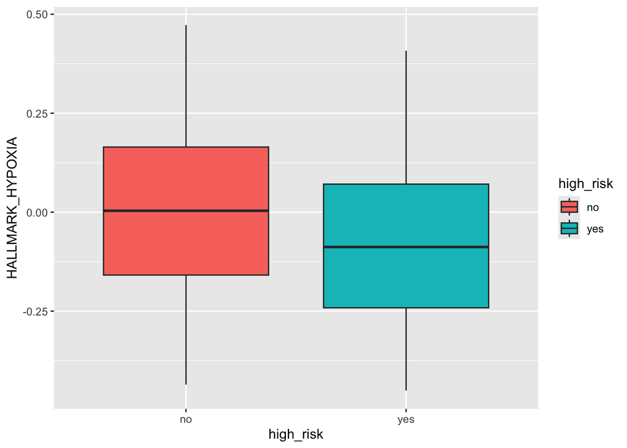

```r
ggplot(r2_gse62564_GSVA_Metadata, aes(x=high_risk, y=HALLMARK_HYPOXIA, fill=high_risk)) +
    geom_boxplot()
```

- This plot suggests that there are components in the HALLMARK_HYPOXIA phenotype responsible for increased hypoxia phenotype in patients of the non-high risk group.
- Surprisingly, these components do not correlate with the HIF1A activation program in the high-risk group
- This finding is the type of information worth reporting in a publication
- Because this concept will appear in a publication, I want to run **statistical** analysis and well as want to make the figure look fancy.

#### Statistical Analysis

In the next chunk, we construct a data-frame with statistics calculations for our plot.

The reference used here was the Kassambara 2023 article:

- (Kassambara 2023)

```r
library(rstatix)
# Statistical test
stat.test <- r2_gse62564_GSVA_Metadata %>%
  t_test(HALLMARK_HYPOXIA ~ high_risk) %>%
  add_significance()
```

We can then look at the statistics dataframe

```r
stat.test
```

| .y. | group1 | group2 | n1 | n2 | statistic | df | p | p.signif |
| --- | --- | --- | --- | --- | --- | --- | --- | --- |
| HALLMARK_HYPOXIA | no | yes | 322 | 176 | 4.446852 | 367.7587 | 1.16e-05 | **** |

In the next chunk, we create the object that will show the statistical results. After, we use the stat_pvalue_manual function.

We also change the theme of the ggplot2 figure plot.

- Make high risk factor:

```r
library(ggpubr)

r2_gse62564_GSVA_Metadata$high_risk <- as.factor(r2_gse62564_GSVA_Metadata$high_risk)
```

Plot high risk vs. HALLMARK_HYPOXIA

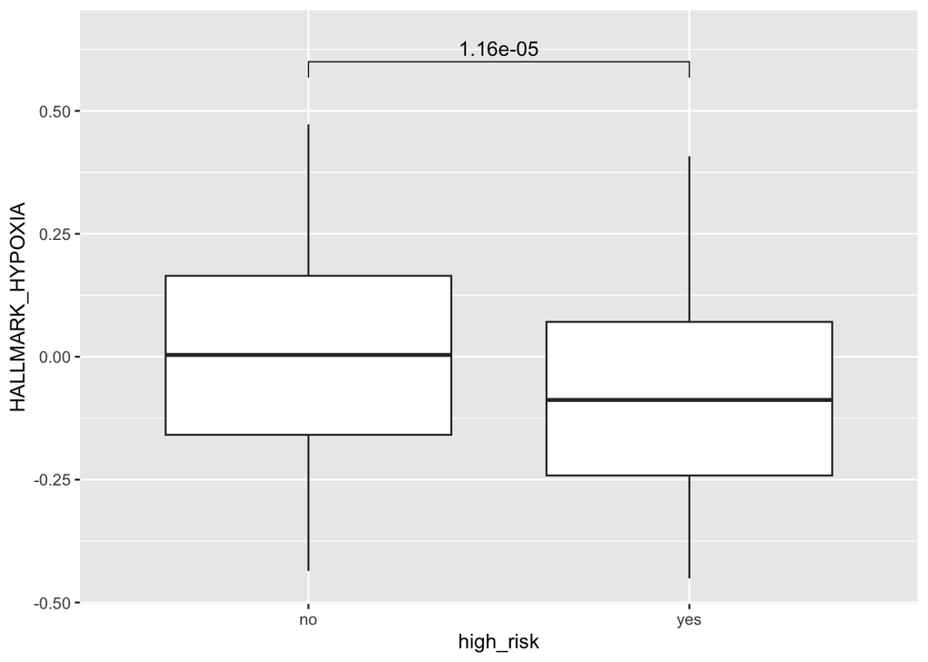

```r
ggplot(r2_gse62564_GSVA_Metadata, aes(x=high_risk, y=HALLMARK_HYPOXIA)) +
    geom_boxplot()+
  stat_pvalue_manual(stat.test, label = "p", y.position = 0.6) + # y.position is mandatory
  scale_y_continuous(expand = expansion(mult = c(0.05, 0.1)))
```

Make HR factor again

```r
r2_gse62564_GSVA_Metadata$high_risk <- as.factor(r2_gse62564_GSVA_Metadata$high_risk)
```

Plot high_risk vs. HALLMARK_HYPOXIA again but with statistics:

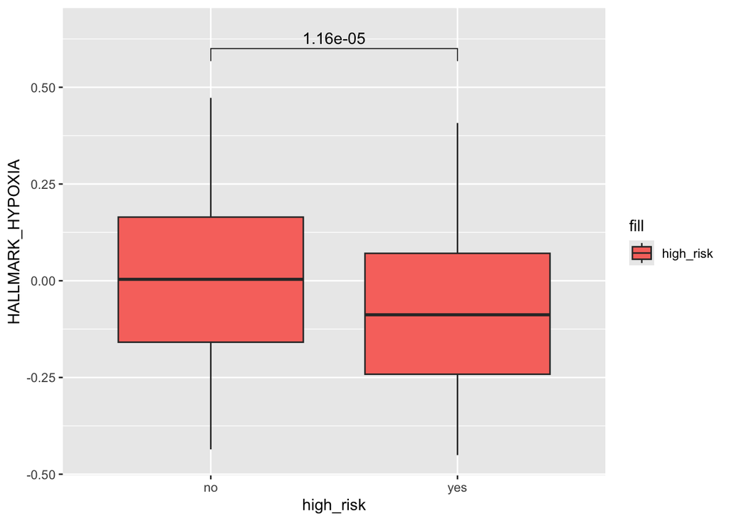

```r
ggplot(r2_gse62564_GSVA_Metadata, aes(x=high_risk, y=HALLMARK_HYPOXIA, fill="high_risk")) +
    geom_boxplot()+
  stat_pvalue_manual(stat.test, label = "p", y.position = 0.6) + # y.position is mandatory
  scale_y_continuous(expand = expansion(mult = c(0.05, 0.1)))
```

Use compare_means function to construct t-test dataframe:

```r
compare_means(data = r2_gse62564_GSVA_Metadata, HALLMARK_HYPOXIA ~ high_risk, method = "t.test")
```

| .y. | group1 | group2 | p | p.adj | p.format | p.signif | method |
| --- | --- | --- | --- | --- | --- | --- | --- |
| HALLMARK_HYPOXIA | no | yes | 1.155677e-05 | 1.2e-05 | 1.2e-05 | **** | T-test |

Plot HR vs. HALLMARK_HYPOXIA with different colors per HR group and different theme:

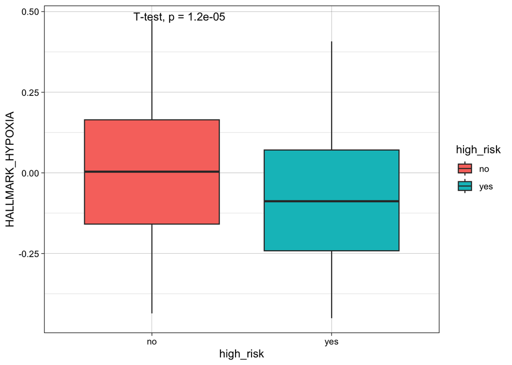

```r
ggplot(r2_gse62564_GSVA_Metadata, aes(x=high_risk, y=HALLMARK_HYPOXIA, fill=high_risk)) +
    geom_boxplot()+
  stat_compare_means(method = "t.test")+
  theme_linedraw()
```

### 4.3. Hypoxia Down-Regulation

#### No statistical analysis

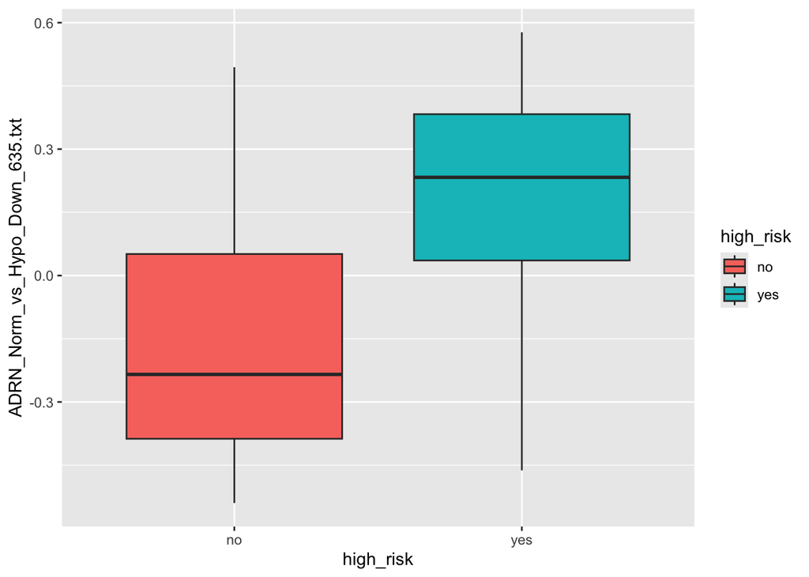

```r
r2_gse62564_GSVA_Metadata$ADRN_Norm_vs_Hypo_Down_635.txt <- as.numeric(r2_gse62564_GSVA_Metadata$ADRN_Norm_vs_Hypo_Down_635.txt)
ggplot(r2_gse62564_GSVA_Metadata, aes(x=high_risk, y=ADRN_Norm_vs_Hypo_Down_635.txt, fill=high_risk)) +
    geom_boxplot()
```

#### Statistical analysis

```r
compare_means(data = r2_gse62564_GSVA_Metadata, ADRN_Norm_vs_Hypo_Down_635.txt ~ high_risk, method = "t.test")
```

| .y. | group1 | group2 | p | p.adj | p.format | p.signif | method |
| --- | --- | --- | --- | --- | --- | --- | --- |
| ADRN_Norm_vs_Hypo_Down_635.txt | no | yes | 4.251694e-35 | 4.3e-35 | <2e-16 | **** | T-test |

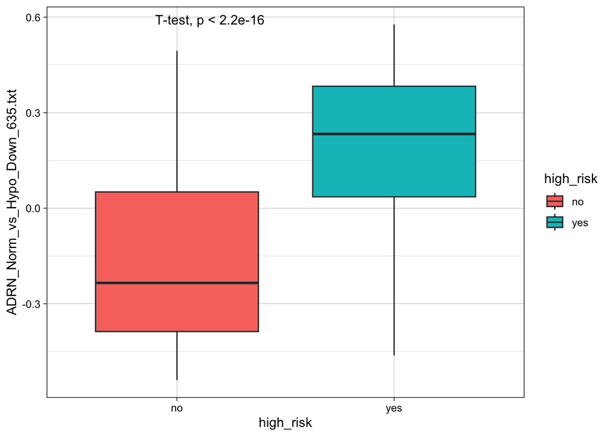

```r
r2_gse62564_GSVA_Metadata$ADRN_Norm_vs_Hypo_Down_635.txt <- as.numeric(r2_gse62564_GSVA_Metadata$ADRN_Norm_vs_Hypo_Down_635.txt)
ggplot(r2_gse62564_GSVA_Metadata, aes(x=high_risk, y=ADRN_Norm_vs_Hypo_Down_635.txt, fill=high_risk)) +
    geom_boxplot()+
  stat_compare_means(method = "t.test")+
  theme_linedraw()
```

### 4.4. Hypoxia Up-Regulation

#### Statistical analysis

Make ADRN_Norm_vs_Hypo_Up_554.txt numeric to avoid error

```r
r2_gse62564_GSVA_Metadata$ADRN_Norm_vs_Hypo_Up_554.txt <- as.numeric(r2_gse62564_GSVA_Metadata$ADRN_Norm_vs_Hypo_Up_554.txt)
```

Run the t-test

```r
compare_means(data = r2_gse62564_GSVA_Metadata, ADRN_Norm_vs_Hypo_Up_554.txt ~ high_risk, method = "t.test")
```

| .y. | group1 | group2 | p | p.adj | p.format | p.signif | method |
| --- | --- | --- | --- | --- | --- | --- | --- |
| ADRN_Norm_vs_Hypo_Up_554.txt | no | yes | 1.131773e-21 | 1.1e-21 | <2e-16 | **** | T-test |

Plot

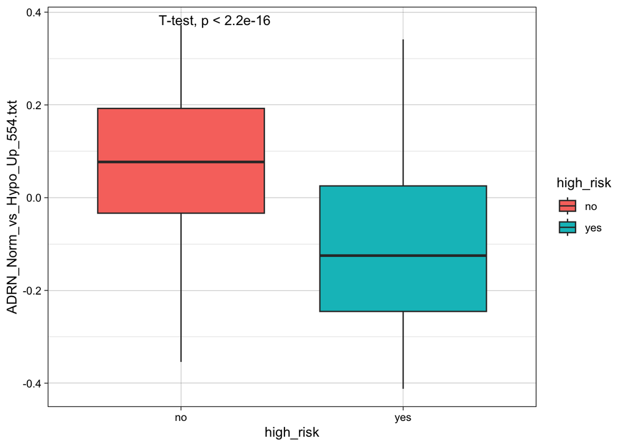

```r
ggplot(r2_gse62564_GSVA_Metadata, aes(x=high_risk, y=ADRN_Norm_vs_Hypo_Up_554.txt, fill=high_risk)) +
    geom_boxplot()+
  stat_compare_means(method = "t.test")+
  theme_linedraw()
```

#### Statistical analysis

The compare_means function can not deal with spaces in the T cell exhaustion variable name.

We will have to use a trick to deal with the spaces in “T cell exhaustion”.

We will use the package stringr to insert dots (.) replacing the spaces in the r2_gse62564_GSVA_Metadata dataframe.

To start, we have to create the r2_gse62564_GSVA_Metadata_Spaces dataframe, which will have structure names that contained spaces, changed to one of these new characteres: “.” , “,”, or ““.

```r
r2_gse62564_GSVA_Metadata_Spaces <- r2_gse62564_GSVA_Metadata
library(stringr)
names(r2_gse62564_GSVA_Metadata_Spaces)<-str_replace_all(names(r2_gse62564_GSVA_Metadata_Spaces), c(" " = "." , "," = "" ))
```

### 4.5. HALLMARK_INFLAMMATORY_RESPONSE

#### No statistical analysis

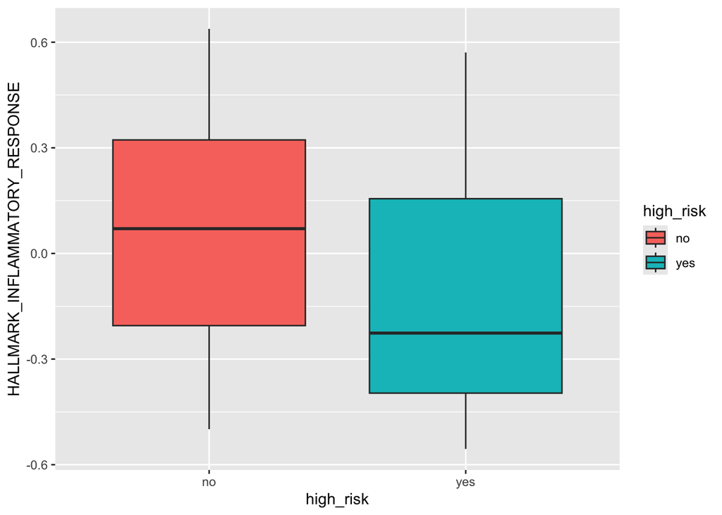

```r
r2_gse62564_GSVA_Metadata$HALLMARK_INFLAMMATORY_RESPONSE <- as.numeric(r2_gse62564_GSVA_Metadata$HALLMARK_INFLAMMATORY_RESPONSE)
ggplot(r2_gse62564_GSVA_Metadata, aes(x=high_risk, y=HALLMARK_INFLAMMATORY_RESPONSE, fill=high_risk)) +
    geom_boxplot()
```

#### Statistical analysis

```r
compare_means(data = r2_gse62564_GSVA_Metadata, HALLMARK_INFLAMMATORY_RESPONSE ~ high_risk, method = "t.test")
```

| .y. | group1 | group2 | p | p.adj | p.format | p.signif | method |
| --- | --- | --- | --- | --- | --- | --- | --- |
| HALLMARK_INFLAMMATORY_RESPONSE | no | yes | 3.998029e-09 | 4e-09 | 4e-09 | **** | T-test |

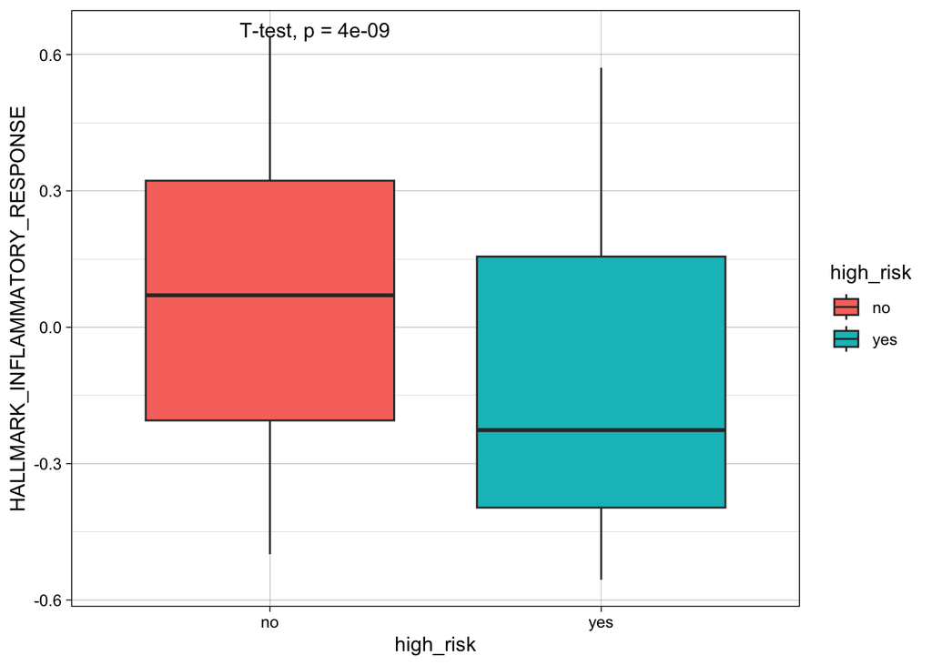

```r
r2_gse62564_GSVA_Metadata$HALLMARK_INFLAMMATORY_RESPONSE <- as.numeric(r2_gse62564_GSVA_Metadata$HALLMARK_INFLAMMATORY_RESPONSE)
ggplot(r2_gse62564_GSVA_Metadata, aes(x=high_risk, y=HALLMARK_INFLAMMATORY_RESPONSE, fill=high_risk)) +
    geom_boxplot()+
  stat_compare_means(method = "t.test")+
  theme_linedraw()
```

# 5. Survival analysis of the hypoxia gene sets

### 5.1. HIF1A

### OS (Overall Survival)

Construct the HIF1A quantile variable:

```r
library(tidyverse)

r2_gse62564_GSVA_Metadata <- r2_gse62564_GSVA_Metadata %>%
    mutate(quantile = ntile(HIF1A, 2))
```

Make the HIF1A quantile variable a factor

```r
r2_gse62564_GSVA_Metadata$quantile <- as.factor(r2_gse62564_GSVA_Metadata$quantile )
```

Scaterplot HALLMARK_HYPOXIA vs. HIF1A

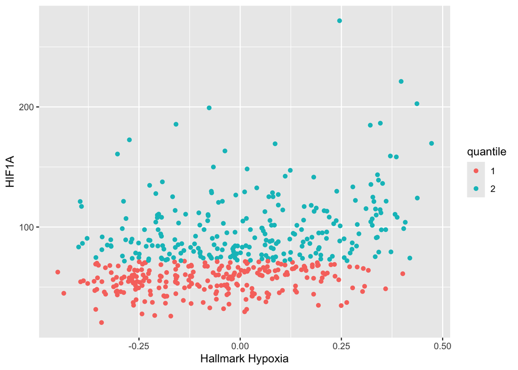

```r
qplot(HALLMARK_HYPOXIA, HIF1A,
      data = r2_gse62564_GSVA_Metadata,
      colour=quantile,
      ylab = "HIF1A",
      xlab = "Hallmark Hypoxia")
```

Construct survival object with HIF1A quantile variable

```r
library(survival)
fit_os_HIF1A <- survfit(Surv(as.numeric(os_day), os_bin_numeric) ~ r2_gse62564_GSVA_Metadata$quantile,
                   data = r2_gse62564_GSVA_Metadata)
```

Plot survival curve OS

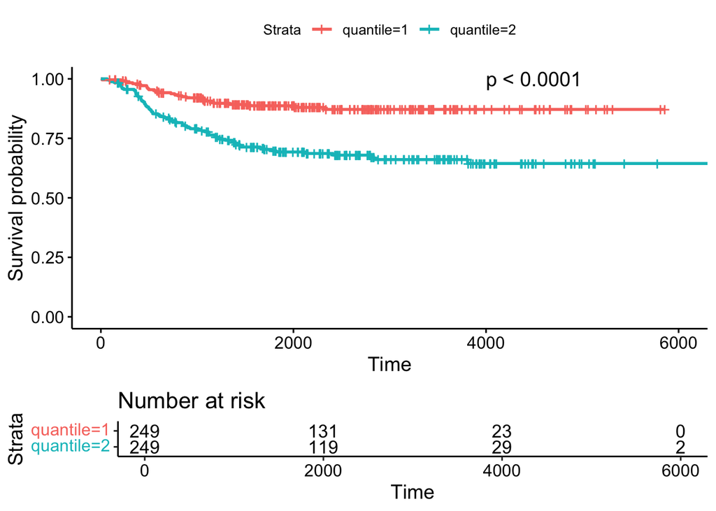

```r
library(survminer)
ggsurvplot(fit_os_HIF1A,
           data = r2_gse62564_GSVA_Metadata,
           risk.table = TRUE,
           # risk.table = "abs_pct",
           pval = TRUE,
           pval.coord = c(4000, 1),
           )
```

### EFS (Event Free Survival)

Construct the HIF1A quantile variable:

```r
library(tidyverse)

r2_gse62564_GSVA_Metadata <- r2_gse62564_GSVA_Metadata %>%
    mutate(quantile = ntile(HIF1A, 2))
```

Construct survival object EFS

```r
library(survival)
fit_efs_HIF1A <- survfit(Surv(as.numeric(efs_day), efs_bin_numeric) ~ r2_gse62564_GSVA_Metadata$quantile,
                   data = r2_gse62564_GSVA_Metadata)
```

Plot survival curve EFS

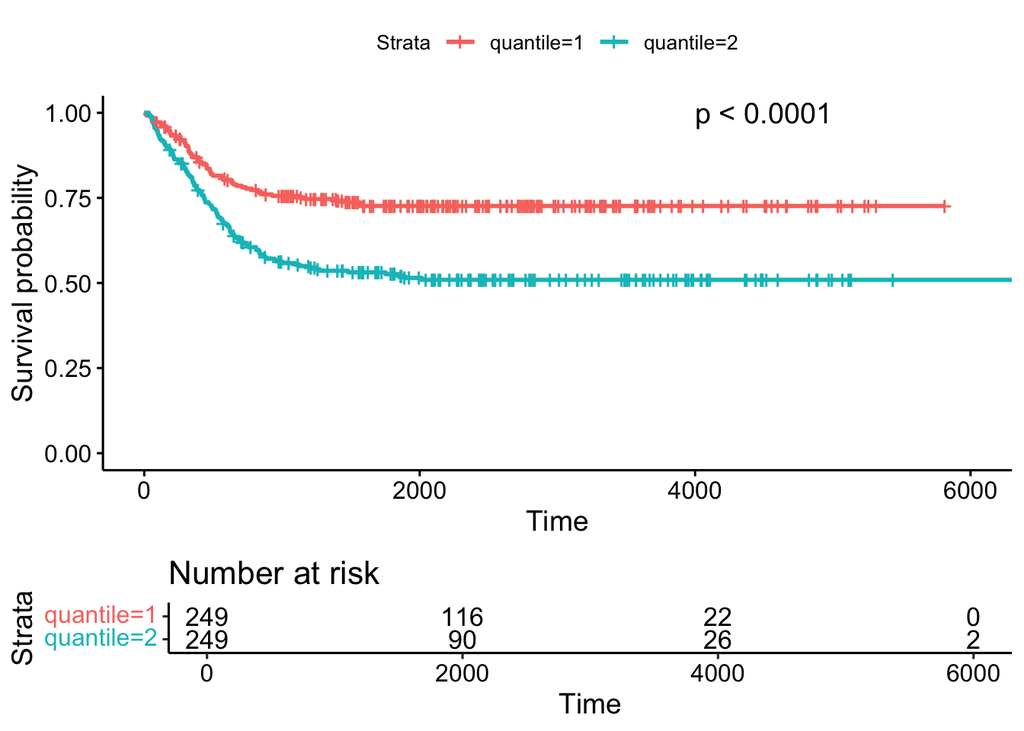

```r
library(survminer)
ggsurvplot(fit_efs_HIF1A,
           data = r2_gse62564_GSVA_Metadata,
           risk.table = TRUE,
           # risk.table = "abs_pct",
           pval = TRUE,
           pval.coord = c(4000, 1),
           )
```

### Create variable r2_gse62564_GSVA_Metadata_Spaces_survival

```r
r2_gse62564_GSVA_Metadata_Spaces_survival <- r2_gse62564_GSVA_Metadata_Spaces
```

# 6. HIF1A relationship to age at diagnosis

### 6.1. HIF1A, age at diagnosis and HR

Make age_at_diagnosis numeric to plot the quantiles

```r
r2_gse62564_GSVA_Metadata_Spaces_survival$age_at_diagnosis <- as.numeric(r2_gse62564_GSVA_Metadata_Spaces_survival$age_at_diagnosis)
```

Check maximum age_at_diagnosis

```r
max(r2_gse62564_GSVA_Metadata_Spaces_survival$age_at_diagnosis)
```

```
## [1] 8983
```

Check minimum age_at_diagnosis

```r
min(r2_gse62564_GSVA_Metadata_Spaces_survival$age_at_diagnosis)
```

```
## [1] 0
```

Construct age_qtls quantiles

```r
r2_gse62564_GSVA_Metadata_Spaces_survival_age <- r2_gse62564_GSVA_Metadata_Spaces_survival %>%
    mutate(age_qtls = ntile(age_at_diagnosis, 4))
```

Make age_qtls factor

```r
r2_gse62564_GSVA_Metadata_Spaces_survival_age$age_qtls <- as.factor(r2_gse62564_GSVA_Metadata_Spaces_survival_age$age_qtls)
```

Plot age_qtls vs. HIF1A

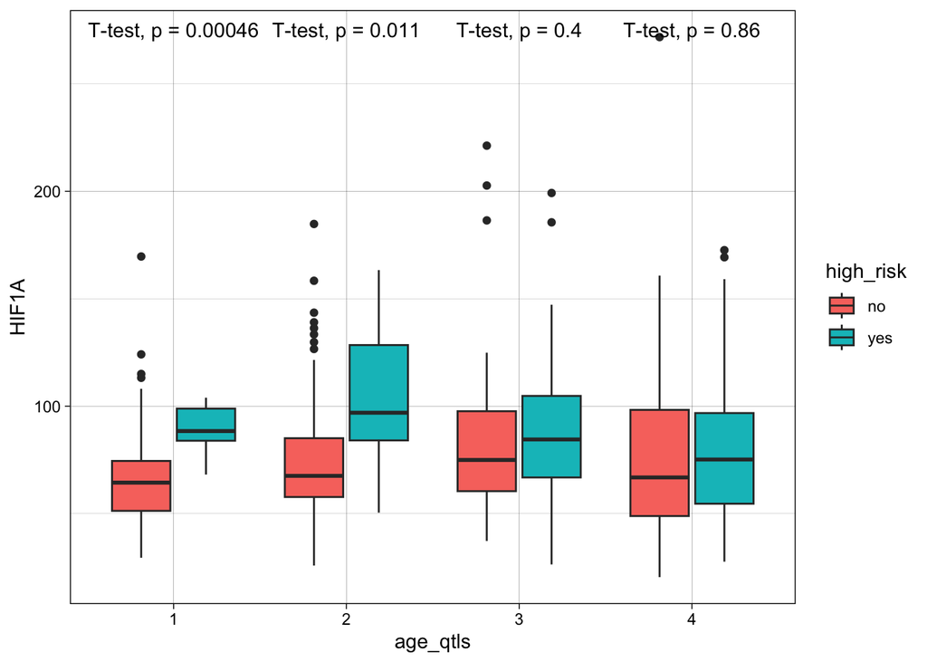

```r
ggplot(r2_gse62564_GSVA_Metadata_Spaces_survival_age, aes(x=age_qtls, y=HIF1A, fill=high_risk)) +
    geom_boxplot()+
  stat_compare_means(method = "t.test")+
  theme_linedraw()
```

### 6.2. HIF1A, age at diagnosis and MYCN status

Divide the age_at_diagnosis variable into several quantiles:

```r
r2_gse62564_GSVA_Metadata_Spaces_survival_age <- r2_gse62564_GSVA_Metadata_Spaces_survival %>%
    mutate(age_qtls = ntile(age_at_diagnosis, 4))
```

Make age_qtls a factor

```r
r2_gse62564_GSVA_Metadata_Spaces_survival_age$age_qtls <- as.factor(r2_gse62564_GSVA_Metadata_Spaces_survival_age$age_qtls)
```

Plot age_qtls vs HIF1A Gene Expression

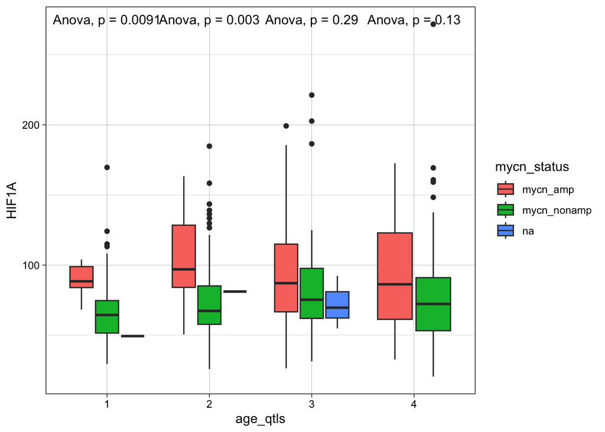

```r
ggplot(r2_gse62564_GSVA_Metadata_Spaces_survival_age, aes(x=age_qtls, y=HIF1A, fill=mycn_status)) +
    geom_boxplot()+
  stat_compare_means(method = "anova")+
  theme_linedraw()
```

Remove the NAs from the mycn_status variable

```r
r2_gse62564_GSVA_Metadata_Spaces_survival_age <- r2_gse62564_GSVA_Metadata_Spaces_survival_age[which(
  r2_gse62564_GSVA_Metadata_Spaces_survival_age$mycn_status != "na"  ), ]
```

Construct age_qtls variable; the number of quantiles can change between 3-4 or more.

```r
r2_gse62564_GSVA_Metadata_Spaces_survival_age <- r2_gse62564_GSVA_Metadata_Spaces_survival_age %>%
    mutate(age_qtls = ntile(age_at_diagnosis, 4))
```

Plot age_qtls vs HIF1A Gene Expression

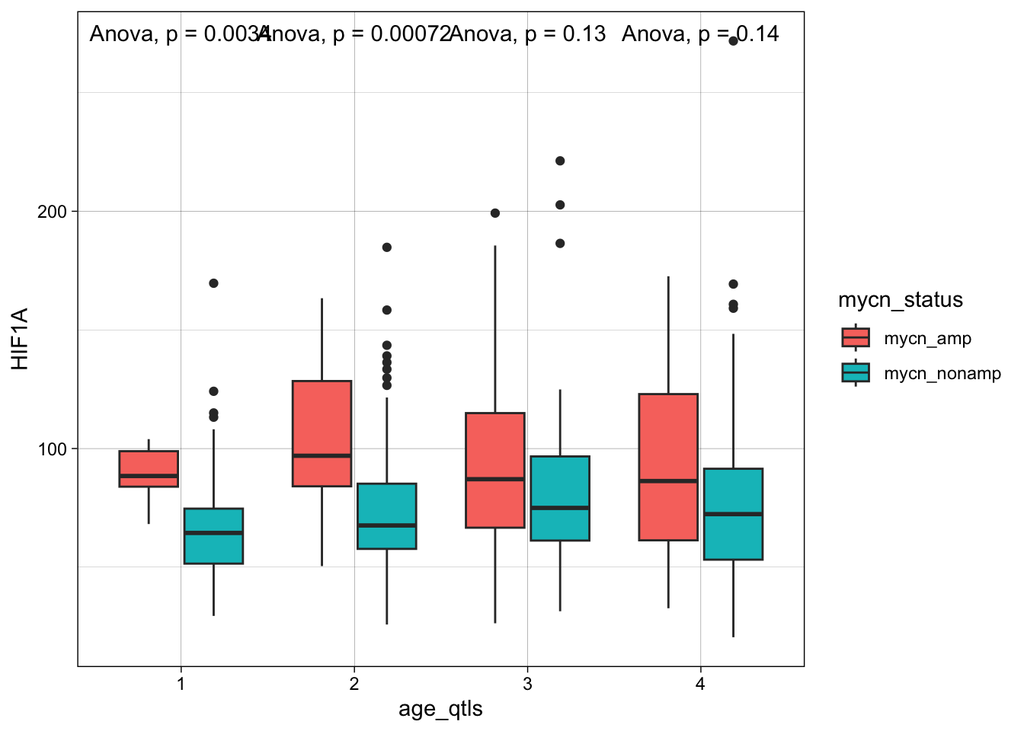

```r
r2_gse62564_GSVA_Metadata_Spaces_survival_age$age_qtls <- as.factor(r2_gse62564_GSVA_Metadata_Spaces_survival_age$age_qtls)
ggplot(r2_gse62564_GSVA_Metadata_Spaces_survival_age, aes(x=age_qtls, y=HIF1A, fill=mycn_status)) +
    geom_boxplot()+
  stat_compare_means(method = "anova")+
  theme_linedraw()
```

##### Note that the difference in HIF1A expression decreases as the age increases

##### How does this affect HIF1A activity in younger children?

```r
saveRDS(r2_gse62564_GSVA_Metadata, file = "~/Desktop/r2_gse62564_GSVA_Metadata.rds")
```

# References

Jaeger, T. Florian. 2015. *Transfer Installed Libraries to a Different Version of r*. https://hlplab.wordpress.com/2012/06/01/transferring-installed-packages-between-different-installations-of-r/.

Kassambara, Alboukadel. 2017. *Add p-Values and Significance Levels to Ggplots*. http://www.sthda.com/english/articles/24-ggpubr-publication-ready-plots/76-add-p-values-and-significance-levels-to-ggplots/.

———. 2023. *How to Add p-Values onto Basic GGPLOTS*. https://www.datanovia.com/en/blog/how-to-add-p-values-onto-basic-ggplots/.

Zabor, Emily C. 2023. *Survival Analysis in r*. https://www.emilyzabor.com/tutorials/survival_analysis_in_r_tutorial.html.